# Chapter 3: Data Manipulation with Pandas

Pandas is built on top of NumPy and provides DataFrames which are essentially multidimensional arrays with attached tow and columns labels, and often with heterogeneous types and/or missing data.

## Installing and Using Pandas

```python
reticulate::repl_python()
import pandas as pd
pandas.__version__
```

```
NameError: name 'pandas' is not defined
```

# Introducing Pandas Objects

To get started, we’ll explore the `Series`, `DataFrame`, and `Index`.

```python
import numpy as np
import pandas as pd
```

## The Pandas Series Object

A Pandas Series is a one-dimensional array of indexed data created as follows:

```python
data = pd.Series([0.25, 0.5, 0.75, 1.0])
data
```

```
0    0.25
1    0.50
2    0.75
3    1.00
dtype: float64
```

Here we get indices and values. Like with NumPy, data can be accessed by the associated index via the square-bracket notation:

```python
data[1]
```

```
0.5
```

```python
data[1:3]
```

```
1    0.50
2    0.75
dtype: float64
```

### `Series` as generalized NumPy array

Pandas series have explicitly defined indices. This means that the index doesn’t need to be an integer. For example:

```python
data = pd.Series(
  [0.25, 0.5, 0.75, 1.0],
  index = ["a", "b", "c", "d"]
)

data
```

```
a    0.25
b    0.50
c    0.75
d    1.00
dtype: float64
```

### Series as specialized dictionary

A Pandas `series` is like a specialization of a Python dictionary. A dictionary is a structure that maps arbitrary keys to a set of types values.

```python
population_dict = {'California': 38332521,
                   'Texas': 26448193,
                   'New York': 19651127,
                   'Florida': 19552860,
                   'Illinois': 12882135}
population = pd.Series(population_dict)
population
```

```
California    38332521
Texas         26448193
New York      19651127
Florida       19552860
Illinois      12882135
dtype: int64
```

```python
population["California"]
```

```
38332521
```

### Constructing series objects

In general, constructing a series follows this format:

```r
pd.Series(data, index = index)
```

## The Pandas DataFrame Object

### DataFrame as a generalized NumPy array

Let’s construct a new `Series`:

```python
area_dict = {'California': 423967, 'Texas': 695662, 'New York': 141297,
             'Florida': 170312, 'Illinois': 149995}
area = pd.Series(area_dict)
area
```

```
California    423967
Texas         695662
New York      141297
Florida       170312
Illinois      149995
dtype: int64
```

We can use the population data from before to construct a single two-dimensional object containing this information:

```python
states = pd.DataFrame({'population': population,
                       'area': area})
states
```

```
            population    area
California    38332521  423967
Texas         26448193  695662
New York      19651127  141297
Florida       19552860  170312
Illinois      12882135  149995
```

We can access the attributes of an index like this:

```python
states.index
```

```
Index(['California', 'Texas', 'New York', 'Florida', 'Illinois'], dtype='object')
```

Or the columns like this:

```python
states.columns
```

```
Index(['population', 'area'], dtype='object')
```

### DataFrame as a specialized dictionary

```python
states["area"]
```

```
California    423967
Texas         695662
New York      141297
Florida       170312
Illinois      149995
Name: area, dtype: int64
```

### Constructing DataFrame objects

#### From a single Series object

```python
pd.DataFrame(population, columns = ["population"])
```

```
            population
California    38332521
Texas         26448193
New York      19651127
Florida       19552860
Illinois      12882135
```

#### From a list of dicts

```python
data = [{'a': i, 'b': 2 * i}
        for i in range(3)]
data
```

```
[{'a': 0, 'b': 0}, {'a': 1, 'b': 2}, {'a': 2, 'b': 4}]
```

```python
pd.DataFrame(data)
```

```
   a  b
0  0  0
1  1  2
2  2  4
```

Even if some of the keys in the dictionary are missing, Pandas will fill them in with `NaN`:

```python
pd.DataFrame([{'a': 1, 'b': 2}, {'b': 3, 'c': 4}])
```

```
     a  b    c
0  1.0  2  NaN
1  NaN  3  4.0
```

#### From a dictionary of Series objects

```python
pd.DataFrame({'population': population,
              'area': area})
```

```
            population    area
California    38332521  423967
Texas         26448193  695662
New York      19651127  141297
Florida       19552860  170312
Illinois      12882135  149995
```

#### From a two-dimensional NumPy array

```python
pd.DataFrame(np.random.rand(3, 2),
             columns=['foo', 'bar'],
             index=['a', 'b', 'c'])
```

```
        foo       bar
a  0.716777  0.509723
b  0.471639  0.644917
c  0.419403  0.613723
```

#### From a NumPy structured array

```python
A = np.zeros(3, dtype=[('A', 'i8'), ('B', 'f8')])
A
```

```
array([(0, 0.), (0, 0.), (0, 0.)], dtype=[('A', '<i8'), ('B', '<f8')])
```

```python
pd.DataFrame(A)
```

```
   A    B
0  0  0.0
1  0  0.0
2  0  0.0
```

## The Pandas Index Object

```python
ind = pd.Index([2, 3, 5, 7, 11])
ind
```

```
Int64Index([2, 3, 5, 7, 11], dtype='int64')
```

### Index as immutable array

```python
ind[1]
```

```
3
```

```python
ind[::2]
```

```
Int64Index([2, 5, 11], dtype='int64')
```

Indices are immutable.

### Index as ordered set

The `Index` object follows many of the conventions used by Python’s built-in `set` data structure, so that unions, intersections, differences, and other combinations can be computed in a familiar way.

```python
indA = pd.Index([1, 3, 5, 7, 9])
indB = pd.Index([2, 3, 5, 7, 11])

# intersection
indA & indB
```

```
Int64Index([3, 5, 7], dtype='int64')
```

```python
# union
indA | indB
```

```
Int64Index([1, 2, 3, 5, 7, 9, 11], dtype='int64')
```

```python
# symmetric difference
indA ^ indB
```

```
Int64Index([1, 2, 9, 11], dtype='int64')
```

# Data Indexing and Selection

## Data Selection in Series

### Series as dictionary

```python
import pandas as pd
data = pd.Series([0.25, 0.5, 0.75, 1.0],
                 index=['a', 'b', 'c', 'd'])
data
```

```
a    0.25
b    0.50
c    0.75
d    1.00
dtype: float64
```

```python
data["b"]
```

```
0.5
```

We can also use dictionary-like Python expressions and methods to examine the keys/indices and values:

```python
"a" in data
```

```
True
```

```python
data.keys()
```

```
Index(['a', 'b', 'c', 'd'], dtype='object')
```

```python
list(data.items())
```

```
[('a', 0.25), ('b', 0.5), ('c', 0.75), ('d', 1.0)]
```

`Series` objects can also be modified with a dictionary-like syntax:

```python
data["e"] = 1.25
data
```

```
a    0.25
b    0.50
c    0.75
d    1.00
e    1.25
dtype: float64
```

### Series as one-dimensional array

A `series` builds on the dictionary-like interface and provides array-style item selection via the same basic mechanisms as NumPy arrays.

```python
data
```

```
a    0.25
b    0.50
c    0.75
d    1.00
e    1.25
dtype: float64
```

```python
# slicing by explicit index
data["a":"c"]
```

```
a    0.25
b    0.50
c    0.75
dtype: float64
```

```python
# slicing by implicit integer index
data[0:2]
```

```
a    0.25
b    0.50
dtype: float64
```

```python
# masking
data[(data > 0.3) & (data < 0.8)]
```

```
b    0.50
c    0.75
dtype: float64
```

```python
# fancy indexing
data[["a", "e"]]
```

```
a    0.25
e    1.25
dtype: float64
```

### Indexers: `loc`, `iloc`, and `ix`

If your `series` has an explicit integer index, an indexing operation such as `data[1]` will use the explicit indices, while a slicing operation like `data[1:3]` will use the Python-style index.

```python
data = pd.Series(['a', 'b', 'c'], index=[1, 3, 5])
data
```

```
1    a
3    b
5    c
dtype: object
```

```python
# explicit index when indexing
data[1]
```

```
'a'
```

```python
# implicit index when slicing
data[1:3]
```

```
3    b
5    c
dtype: object
```

To avoid confusion, Pandas provides some special indexer attributes. First, the `loc` attribute allows indexing and slicing that always references the explicit index:

```python
data.loc[1]
```

```
'a'
```

```python
data.loc[1:3]
```

```
1    a
3    b
dtype: object
```

The `iloc` attribute allows indexing and slicing that always references the implicit Python-style index:

```python
data.iloc[1]
```

```
'b'
```

```python
data.iloc[1:3]
```

```
3    b
5    c
dtype: object
```

## Data Selection in DataFrame

### DataFrame as a dictionary

```python
area = pd.Series({'California': 423967, 'Texas': 695662,
                  'New York': 141297, 'Florida': 170312,
                  'Illinois': 149995})
pop = pd.Series({'California': 38332521, 'Texas': 26448193,
                 'New York': 19651127, 'Florida': 19552860,
                 'Illinois': 12882135})
data = pd.DataFrame({'area':area, 'pop':pop})
data
```

```
              area       pop
California  423967  38332521
Texas       695662  26448193
New York    141297  19651127
Florida     170312  19552860
Illinois    149995  12882135
```

The `series` that make up the columns of the `DataFrame` can be accessed via dictionary-style indexing of the column name:

```python
data["area"]
```

```
California    423967
Texas         695662
New York      141297
Florida       170312
Illinois      149995
Name: area, dtype: int64
```

We can also use attribute-style access with column names that are strings:

```python
data.area
```

```
California    423967
Texas         695662
New York      141297
Florida       170312
Illinois      149995
Name: area, dtype: int64
```

```python
data.area is data["area"]
```

```
True
```

Dictionary-style syntax can also be used to modify the object, in this case adding a new column:

```python
data['density'] = data['pop'] / data['area']
data
```

```
              area       pop     density
California  423967  38332521   90.413926
Texas       695662  26448193   38.018740
New York    141297  19651127  139.076746
Florida     170312  19552860  114.806121
Illinois    149995  12882135   85.883763
```

### DataFrame as two-dimensional array

```python
data.values
```

```
array([[4.23967000e+05, 3.83325210e+07, 9.04139261e+01],
       [6.95662000e+05, 2.64481930e+07, 3.80187404e+01],
       [1.41297000e+05, 1.96511270e+07, 1.39076746e+02],
       [1.70312000e+05, 1.95528600e+07, 1.14806121e+02],
       [1.49995000e+05, 1.28821350e+07, 8.58837628e+01]])
```

We can swap rows and columns like this:

```python
data.T
```

```
           California         Texas      New York       Florida      Illinois
area     4.239670e+05  6.956620e+05  1.412970e+05  1.703120e+05  1.499950e+05
pop      3.833252e+07  2.644819e+07  1.965113e+07  1.955286e+07  1.288214e+07
density  9.041393e+01  3.801874e+01  1.390767e+02  1.148061e+02  8.588376e+01
```

Passing a single index to an array accesses a row:

```python
data.values[0]
```

```
array([4.23967000e+05, 3.83325210e+07, 9.04139261e+01])
```

and passing a single “index” to a DataFrame accesses a column:

```python
data["area"]
```

```
California    423967
Texas         695662
New York      141297
Florida       170312
Illinois      149995
Name: area, dtype: int64
```

So, for array-style indexing, we need another convention. Using the `iloc` indexer, we can index the underlying array as if it is a simple NumPy array, but the DataFrame index and column labels are maintained in the result:

```python
data.iloc[:3, :2]
```

```
              area       pop
California  423967  38332521
Texas       695662  26448193
New York    141297  19651127
```

We can index the underlying data in an array-like style but using the explicit index and column names:

```python
data.loc[:'Illinois', :'pop']
```

```
              area       pop
California  423967  38332521
Texas       695662  26448193
New York    141297  19651127
Florida     170312  19552860
Illinois    149995  12882135
```

The `ix` indexer allows a hybrid of these two approaches:

```python
data.ix[:3, :"pop"]
```

```
AttributeError: 'DataFrame' object has no attribute 'ix'
```

With the `loc` indexer, we can combine masking and fancy indexing as in the following:

```python
data.loc[data.density > 100, ["pop", "density"]]
```

```
               pop     density
New York  19651127  139.076746
Florida   19552860  114.806121
```

### Additional indexing conventions

While indexing refers to columns, slicing refers to rows:

```python
data["Florida":"Illinois"]
```

```
            area       pop     density
Florida   170312  19552860  114.806121
Illinois  149995  12882135   85.883763
```

Such slices can also refer to tows by number rather than index:

```python
data[1:3]
```

```
            area       pop     density
Texas     695662  26448193   38.018740
New York  141297  19651127  139.076746
```

Direct masking operations are also interpreted row-wise rather than column-wise:

```python
data[data.density > 100]
```

```
            area       pop     density
New York  141297  19651127  139.076746
Florida   170312  19552860  114.806121
```

# Operating on Data in Pandas

Pandas inherits ufuncs from NumPy. One difference is that Pandas will preserve index and column labels in the output.

## Ufuncs: Index Preservation

NumPy ufuncs will work on Pandas `Series` and `DataFrame` objects.

```python
import pandas as pd
import numpy as np

rng = np.random.RandomState(42)
ser = pd.Series(rng.randint(0, 10, 4))
ser
```

```
0    6
1    3
2    7
3    4
dtype: int64
```

```python
df = pd.DataFrame(rng.randint(0, 10, (3, 4)),
                              columns = ["A", "B", "C", "D"])
df
```

```
   A  B  C  D
0  6  9  2  6
1  7  4  3  7
2  7  2  5  4
```

If we apply a NumPy ufunc on either of these objects, the result will be another Pandas object *with the indices preserved*:

```python
np.exp(ser)
```

```
0     403.428793
1      20.085537
2    1096.633158
3      54.598150
dtype: float64
```

```python
np.sin(df * np.pi / 4)
```

```
          A             B         C             D
0 -1.000000  7.071068e-01  1.000000 -1.000000e+00
1 -0.707107  1.224647e-16  0.707107 -7.071068e-01
2 -0.707107  1.000000e+00 -0.707107  1.224647e-16
```

## Ufuncs: Index Alignment

For binary operations, Pandas will Align indices in the process of performing the operation.

### Index alignment in Series

As an example, suppose we are combining two different data sources, and find only the top three US states by area and the top three US states by population:

```python
area = pd.Series({'Alaska': 1723337, 'Texas': 695662,
                  'California': 423967}, name='area')

population = pd.Series({'California': 38332521, 'Texas': 26448193,
                        'New York': 19651127}, name='population')
```

Let’s see what happens when we divide these to compute population density:

```python
population / area
```

```
Alaska              NaN
California    90.413926
New York            NaN
Texas         38.018740
dtype: float64
```

### Index alignment in DataFrame

A similar type of alignment takes place for *both* columns and indices when performing operations on `DataFrame`s:

```python
A = pd.DataFrame(rng.randint(0, 20, (2, 2)),
                 columns=list('AB'))
A
```

```
   A   B
0  1  11
1  5   1
```

```python
B = pd.DataFrame(rng.randint(0, 10, (3, 3)),
                 columns=list('BAC'))
B
```

```
   B  A  C
0  4  0  9
1  5  8  0
2  9  2  6
```

```python
A + B
```

```
      A     B   C
0   1.0  15.0 NaN
1  13.0   6.0 NaN
2   NaN   NaN NaN
```

## Ufuncs: Operations Between DataFrame and Series

The index alignment is maintained when performing operations between DataFrames and Series.

# Handling Missing Data

## Trade-Offs in Missing Data Conventions

There are two main strategies to indicate the presence of missing data: using a *mask* or choosing a *sentinel value*.

## Missing Data in Pandas

Pandas uses sentinels for missing data `NaN` and the `None` object.

### `None`: Pythonic missing data

```python
import numpy as np
import pandas as pd

vals1 = np.array([1, None, 3, 4])
vals1
```

```
array([1, None, 3, 4], dtype=object)
```

If we let this be considered an object, then aggregations like `sum()` or `min()` across an array with a `None` will produce an error.

### `NaN`: Missing numerical data

`NaN` values are different because they support fast operations.

```python
vals2 = np.array([1, np.nan, 3, 4])
vals2.dtype
```

```
dtype('float64')
```

When preforming aggregates over `NaN` values doesn’t produce an error, but it returns `NaN`s:

```python
vals2.sum(), vals2.min(), vals2.max()
```

```
(nan, nan, nan)
```

NumPy provides special aggregations that ignore these missing values:

```python
np.nansum(vals2), np.nanmin(vals2), np.nanmax(vals2)
```

```
(8.0, 1.0, 4.0)
```

### `NaN` and `None` in Pandas

Pandas handles both `NaN` and `None` interchangeably:

```python
pd.Series([1, np.nan, 2, None])
```

```
0    1.0
1    NaN
2    2.0
3    NaN
dtype: float64
```

Pandas automaticaly converts the `None` to a `NaN` value.

## Operating on Null Values

There are several methods for detecting, removing, and replacing null values in Pandas:

- `isnull()`: Generate a boolean mask indicating missing values
- `notnull()`: Opposite of `isnull()`
- `dropna()`: Return a filtered version of the data
- `fillna()`: Return a copy of the data with missing values filled or imputed

### Detecting null values

```python
data = pd.Series([1, np.nan, "hello", None])
data.isnull()
```

```
0    False
1     True
2    False
3     True
dtype: bool
```

```python
data[data.notnull()]
```

```
0        1
2    hello
dtype: object
```

### Dropping null values

```python
data.dropna()
```

```
0        1
2    hello
dtype: object
```

There are more options for a `DataFrame`:

```python
df = pd.DataFrame([[1,      np.nan, 2],
                   [2,      3,      5],
                   [np.nan, 4,      6]])
df
```

```
     0    1  2
0  1.0  NaN  2
1  2.0  3.0  5
2  NaN  4.0  6
```

By default, `dropna()` will drop all rows in which *any* null value is present:

```python
df.dropna()
```

```
     0    1  2
1  2.0  3.0  5
```

You can also drop along a different axis, like columns with `axis = 1`:

```python
df.dropna(axis = "columns")
```

```
   2
0  2
1  5
2  6
```

You can change how much data is dropped with the `how` and `thresh` parameters.

```python
df[3] = np.nan
df
```

```
     0    1  2   3
0  1.0  NaN  2 NaN
1  2.0  3.0  5 NaN
2  NaN  4.0  6 NaN
```

```python
df.dropna(axis = "columns", how = "all")
```

```
     0    1  2
0  1.0  NaN  2
1  2.0  3.0  5
2  NaN  4.0  6
```

```python
df.dropna(axis = "rows", thresh = 3)
```

```
     0    1  2   3
1  2.0  3.0  5 NaN
```

### Filling null values

Instead of dropping `NA` values, we can also replace them with another value.

These methods also work with `DataFrame`s:

```python
df
```

```
     0    1  2   3
0  1.0  NaN  2 NaN
1  2.0  3.0  5 NaN
2  NaN  4.0  6 NaN
```

```python
df.fillna(method = "ffill", axis = 1)
```

```
     0    1    2    3
0  1.0  1.0  2.0  2.0
1  2.0  3.0  5.0  5.0
2  NaN  4.0  6.0  6.0
```

# Hierarchical Indexing

Hierarchical indexing is used to incorporate multiple index levels within a single index. Here we explore the creation of `MultiIndex` objects.

```python
import pandas as pd
import numpy as np
```

## A multiply Indexed Series

We’ll start by looking at how we can represent two-dimensional data within a one-dimensional `Series`.

### The better way: Pandas Multindex

Suppose you want to track data about states from two different years.

```python
index = [('California', 2000), ('California', 2010),
         ('New York', 2000), ('New York', 2010),
         ('Texas', 2000), ('Texas', 2010)]
populations = [33871648, 37253956,
               18976457, 19378102,
               20851820, 25145561]
pop = pd.Series(populations, index=index)
pop
```

```
(California, 2000)    33871648
(California, 2010)    37253956
(New York, 2000)      18976457
(New York, 2010)      19378102
(Texas, 2000)         20851820
(Texas, 2010)         25145561
dtype: int64
```

```python
index = pd.MultiIndex.from_tuples(index)
index
```

```
MultiIndex([('California', 2000),
            ('California', 2010),
            (  'New York', 2000),
            (  'New York', 2010),
            (     'Texas', 2000),
            (     'Texas', 2010)],
           )
```

```python
pop = pop.reindex(index)
pop
```

```
California  2000    33871648
            2010    37253956
New York    2000    18976457
            2010    19378102
Texas       2000    20851820
            2010    25145561
dtype: int64
```

```python
pop[:, 2010]
```

```
California    37253956
New York      19378102
Texas         25145561
dtype: int64
```

### MultiIndex as extra dimension

Instead of storing the data in rows, we could have used columns:

```python
pop_df = pop.unstack()
pop_df
```

```
                2000      2010
California  33871648  37253956
New York    18976457  19378102
Texas       20851820  25145561
```

`stack()` puts the data back:

```python
pop_df.stack()
```

```
California  2000    33871648
            2010    37253956
New York    2000    18976457
            2010    19378102
Texas       2000    20851820
            2010    25145561
dtype: int64
```

## Methods of MultiIndex Creation

The easiest way to construct a multiply indexed `Series` or `DataFrame` is to pass a list of two or more index arrays to the constructor:

```python
df = pd.DataFrame(np.random.rand(4, 2),
                  index=[['a', 'a', 'b', 'b'], [1, 2, 1, 2]],
                  columns=['data1', 'data2'])
df
```

```
        data1     data2
a 1  0.423792  0.167374
  2  0.770179  0.916694
b 1  0.545039  0.453276
  2  0.959497  0.047163
```

Or:

```python
data = {('California', 2000): 33871648,
        ('California', 2010): 37253956,
        ('Texas', 2000): 20851820,
        ('Texas', 2010): 25145561,
        ('New York', 2000): 18976457,
        ('New York', 2010): 19378102}
pd.Series(data)
```

```
California  2000    33871648
            2010    37253956
Texas       2000    20851820
            2010    25145561
New York    2000    18976457
            2010    19378102
dtype: int64
```

### Explicit MultiIndex constructors

You can also use the class method construtors available in the `pd.MultiIndex`:

```python
pd.MultiIndex.from_arrays([['a', 'a', 'b', 'b'], [1, 2, 1, 2]])
```

```
MultiIndex([('a', 1),
            ('a', 2),
            ('b', 1),
            ('b', 2)],
           )
```

# Combining Datasets: Concat and Append

Here we look at how to concatenate `Series` and `DataFrame`s.

```python
import pandas as pd
import numpy as np

# function to quickly make a DataFrame
def make_df(cols, ind):
    """Quickly make a DataFrame"""
    data = {c: [str(c) + str(i) for i in ind]
            for c in cols}
    return pd.DataFrame(data, ind)

# example DataFrame
make_df('ABC', range(3))
```

```
    A   B   C
0  A0  B0  C0
1  A1  B1  C1
2  A2  B2  C2
```

```python
# class that allows for display of multiple `DataFrames` side by side
class display(object):
    """Display HTML representation of multiple objects"""
    template = """<div style="float: left; padding: 10px;">
    <p style='font-family:"Courier New", Courier, monospace'>{0}</p>{1}
    </div>"""
    def __init__(self, *args):
        self.args = args

    def _repr_html_(self):
        return '\n'.join(self.template.format(a, eval(a)._repr_html_())
                         for a in self.args)

    def __repr__(self):
        return '\n\n'.join(a + '\n' + repr(eval(a))
                           for a in self.args)
```

## Recall: Concatenation of NumPy Arrays

You can combine NumPy arrays with `np.concatenate`

```python
x = [1, 2, 3]
y = [4, 5, 6]
z = [7, 8, 9]
np.concatenate([x, y, z])
```

```
array([1, 2, 3, 4, 5, 6, 7, 8, 9])
```

## Simple Concatenation with `pd.concat`

`pd.concat()` works in a similar with but provides a number of different options:

```r
pd.concat(objs, axis=0, join='outer', join_axes=None, ignore_index=False,
          keys=None, levels=None, names=None, verify_integrity=False,
          copy=True)
```

```python
ser1 = pd.Series(['A', 'B', 'C'], index=[1, 2, 3])
ser2 = pd.Series(['D', 'E', 'F'], index=[4, 5, 6])
pd.concat([ser1, ser2])
```

```
1    A
2    B
3    C
4    D
5    E
6    F
dtype: object
```

You can also concatenate `DataFrames`:

```python
df1 = make_df('AB', [1, 2])
df2 = make_df('AB', [3, 4])
display('df1', 'df2', 'pd.concat([df1, df2])')
```

```
df1
    A   B
1  A1  B1
2  A2  B2

df2
    A   B
3  A3  B3
4  A4  B4

pd.concat([df1, df2])
    A   B
1  A1  B1
2  A2  B2
3  A3  B3
4  A4  B4
```

### Duplicate indices

Pandas concatenation *preserves indices* where NumPy concatenations do not.

```python
x = make_df('AB', [0, 1])
y = make_df('AB', [2, 3])
y.index = x.index  # make duplicate indices!
display('x', 'y', 'pd.concat([x, y])')
```

```
x
    A   B
0  A0  B0
1  A1  B1

y
    A   B
0  A2  B2
1  A3  B3

pd.concat([x, y])
    A   B
0  A0  B0
1  A1  B1
0  A2  B2
1  A3  B3
```

### Concatenation with joins

Concatenations works well when we have two datasets with the same column names. Consider concatenation of two `DataFrames` which don’t have all columns in common:

```python
df5 = make_df('ABC', [1, 2])
df6 = make_df('BCD', [3, 4])
display('df5', 'df6', 'pd.concat([df5, df6])')
```

```
df5
    A   B   C
1  A1  B1  C1
2  A2  B2  C2

df6
    B   C   D
3  B3  C3  D3
4  B4  C4  D4

pd.concat([df5, df6])
     A   B   C    D
1   A1  B1  C1  NaN
2   A2  B2  C2  NaN
3  NaN  B3  C3   D3
4  NaN  B4  C4   D4
```

We can change how the `NA` values are handled with the `join` option. By default, the join is a union of the input columns (`join = "outer"`), but we can change this to an intersection of the columns using `join = "inner"`:

```python
display('df5', 'df6', "pd.concat([df5, df6], join='inner')")
```

```
df5
    A   B   C
1  A1  B1  C1
2  A2  B2  C2

df6
    B   C   D
3  B3  C3  D3
4  B4  C4  D4

pd.concat([df5, df6], join='inner')
    B   C
1  B1  C1
2  B2  C2
3  B3  C3
4  B4  C4
```

### The `append()` method

Rather than calling `pd.concat([df1, df2])`, you can call `df1.append(df2`:

```python
display("df1", "df2", "df1.append(df2)")
```

```
df1
    A   B
1  A1  B1
2  A2  B2

df2
    A   B
3  A3  B3
4  A4  B4

df1.append(df2)
    A   B
1  A1  B1
2  A2  B2
3  A3  B3
4  A4  B4
```

# Combining Datasets: Merge and Join

Merge operations in Pandas are accomplished with the `pd.merge` function.

## Categories of Joins

### One-to-one joins

These are the simplest type of joins and are similar to column-wise concatenation. Consider the following DataFrames which contain information on several employees in a company:

```python
df1 = pd.DataFrame({'employee': ['Bob', 'Jake', 'Lisa', 'Sue'],
                    'group': ['Accounting', 'Engineering', 'Engineering', 'HR']})
df2 = pd.DataFrame({'employee': ['Lisa', 'Bob', 'Jake', 'Sue'],
                    'hire_date': [2004, 2008, 2012, 2014]})
display('df1', 'df2')
```

```
df1
  employee        group
0      Bob   Accounting
1     Jake  Engineering
2     Lisa  Engineering
3      Sue           HR

df2
  employee  hire_date
0     Lisa       2004
1      Bob       2008
2     Jake       2012
3      Sue       2014
```

We combine this into a single DataFrame with `pd.merge`:

```python
df3 = pd.merge(df1, df2)
df3
```

```
  employee        group  hire_date
0      Bob   Accounting       2008
1     Jake  Engineering       2012
2     Lisa  Engineering       2004
3      Sue           HR       2014
```

### Many-to-one joins

Many-to-one joins are jons in which one of the two key columns contains duplicate entries.

```python
df4 = pd.DataFrame({'group': ['Accounting', 'Engineering', 'HR'],
                    'supervisor': ['Carly', 'Guido', 'Steve']})
display('df3', 'df4', 'pd.merge(df3, df4)')
```

```
df3
  employee        group  hire_date
0      Bob   Accounting       2008
1     Jake  Engineering       2012
2     Lisa  Engineering       2004
3      Sue           HR       2014

df4
         group supervisor
0   Accounting      Carly
1  Engineering      Guido
2           HR      Steve

pd.merge(df3, df4)
  employee        group  hire_date supervisor
0      Bob   Accounting       2008      Carly
1     Jake  Engineering       2012      Guido
2     Lisa  Engineering       2004      Guido
3      Sue           HR       2014      Steve
```

### Many-to-many joins

If the key column in both the left and right array contains duplicates, then the result is a many-to-many merge.

```python
df5 = pd.DataFrame({'group': ['Accounting', 'Accounting',
                              'Engineering', 'Engineering', 'HR', 'HR'],
                    'skills': ['math', 'spreadsheets', 'coding', 'linux',
                               'spreadsheets', 'organization']})
display('df1', 'df5', "pd.merge(df1, df5)")
```

```
df1
  employee        group
0      Bob   Accounting
1     Jake  Engineering
2     Lisa  Engineering
3      Sue           HR

df5
         group        skills
0   Accounting          math
1   Accounting  spreadsheets
2  Engineering        coding
3  Engineering         linux
4           HR  spreadsheets
5           HR  organization

pd.merge(df1, df5)
  employee        group        skills
0      Bob   Accounting          math
1      Bob   Accounting  spreadsheets
2     Jake  Engineering        coding
3     Jake  Engineering         linux
4     Lisa  Engineering        coding
5     Lisa  Engineering         linux
6      Sue           HR  spreadsheets
7      Sue           HR  organization
```

## Specification of the Merge Key

The default behavior of `pd.merge` is to look for one or more matching column names between the two inputs, and use this as the key. But the column names do not always match and there are a number of options for dealing with this.

### The `on` keyword

You can specify the name of the key column using the `on` keyword, which takes a column name or a list of column names:

```python
display('df1', 'df2', "pd.merge(df1, df2, on='employee')")
```

```
df1
  employee        group
0      Bob   Accounting
1     Jake  Engineering
2     Lisa  Engineering
3      Sue           HR

df2
  employee  hire_date
0     Lisa       2004
1      Bob       2008
2     Jake       2012
3      Sue       2014

pd.merge(df1, df2, on='employee')
  employee        group  hire_date
0      Bob   Accounting       2008
1     Jake  Engineering       2012
2     Lisa  Engineering       2004
3      Sue           HR       2014
```

### The `left_on` and `right_on` keywords

We can use `left_on` and `right_on` to merge datasets that have different names for the key columns.

```python
df3 = pd.DataFrame({'name': ['Bob', 'Jake', 'Lisa', 'Sue'],
                    'salary': [70000, 80000, 120000, 90000]})
display('df1', 'df3', 'pd.merge(df1, df3, left_on="employee", right_on="name")')
```

```
df1
  employee        group
0      Bob   Accounting
1     Jake  Engineering
2     Lisa  Engineering
3      Sue           HR

df3
   name  salary
0   Bob   70000
1  Jake   80000
2  Lisa  120000
3   Sue   90000

pd.merge(df1, df3, left_on="employee", right_on="name")
  employee        group  name  salary
0      Bob   Accounting   Bob   70000
1     Jake  Engineering  Jake   80000
2     Lisa  Engineering  Lisa  120000
3      Sue           HR   Sue   90000
```

This results in a redundant column that we can drop with the `drop()` method:

```python
pd.merge(df1, df3, left_on = "employee", right_on = "name").drop("name", axis = 1)
```

```
  employee        group  salary
0      Bob   Accounting   70000
1     Jake  Engineering   80000
2     Lisa  Engineering  120000
3      Sue           HR   90000
```

### The `left_index` and `right_index` keywords

Instead of merging on a column, you might want to merge on an index. For example, your data might look like this:

```python
df1a = df1.set_index('employee')
df2a = df2.set_index('employee')
display('df1a', 'df2a')
```

```
df1a
                group
employee
Bob        Accounting
Jake      Engineering
Lisa      Engineering
Sue                HR

df2a
          hire_date
employee
Lisa           2004
Bob            2008
Jake           2012
Sue            2014
```

You can use the index as the key for merging by specifying the `left_index` and/or `right_index` flags in `pd.merge()`:

```python
df1a
```

```
                group
employee
Bob        Accounting
Jake      Engineering
Lisa      Engineering
Sue                HR
```

```python
df2a
```

```
          hire_date
employee
Lisa           2004
Bob            2008
Jake           2012
Sue            2014
```

```python
pd.merge(df1a, df2a, left_index = True, right_index = True)
```

```
                group  hire_date
employee
Bob        Accounting       2008
Jake      Engineering       2012
Lisa      Engineering       2004
Sue                HR       2014
```

DataFrames implement the `join()` method, which performs a merge that defaults to joining on indices.

## Specifying Set Arithmetic for Joins

```python
df6 = pd.DataFrame({'name': ['Peter', 'Paul', 'Mary'],
                    'food': ['fish', 'beans', 'bread']},
                   columns=['name', 'food'])
df7 = pd.DataFrame({'name': ['Mary', 'Joseph'],
                    'drink': ['wine', 'beer']},
                   columns=['name', 'drink'])
display('df6', 'df7', 'pd.merge(df6, df7)')
```

```
df6
    name   food
0  Peter   fish
1   Paul  beans
2   Mary  bread

df7
     name drink
0    Mary  wine
1  Joseph  beer

pd.merge(df6, df7)
   name   food drink
0  Mary  bread  wine
```

By default, `pd.merge` uses the intersection of the two sets which is known as an *inner* join. Other options are `outer`, `left`, and `right`.

An *outer join* returns a join over the union of the input columns, and fills in all missing values with `NA`s:

```python
pd.merge(df6, df7, how = "outer")
```

```
     name   food drink
0   Peter   fish   NaN
1    Paul  beans   NaN
2    Mary  bread  wine
3  Joseph    NaN  beer
```

The *left join* and *right join* return joins over the left entries and right entries, respectively.

```python
pd.merge(df6, df7, how = "left")
```

```
    name   food drink
0  Peter   fish   NaN
1   Paul  beans   NaN
2   Mary  bread  wine
```

```python
pd.merge(df6, df7, how = "right")
```

```
     name   food drink
0    Mary  bread  wine
1  Joseph    NaN  beer
```

## Overlapping Column Names: The `suffixes` Keyword

You may end up in a case where your two input DataFrames have conflicting column names:

```python
df8 = pd.DataFrame({'name': ['Bob', 'Jake', 'Lisa', 'Sue'],
                    'rank': [1, 2, 3, 4]})
df9 = pd.DataFrame({'name': ['Bob', 'Jake', 'Lisa', 'Sue'],
                    'rank': [3, 1, 4, 2]})
display('df8', 'df9', 'pd.merge(df8, df9, on="name")')
```

```
df8
   name  rank
0   Bob     1
1  Jake     2
2  Lisa     3
3   Sue     4

df9
   name  rank
0   Bob     3
1  Jake     1
2  Lisa     4
3   Sue     2

pd.merge(df8, df9, on="name")
   name  rank_x  rank_y
0   Bob       1       3
1  Jake       2       1
2  Lisa       3       4
3   Sue       4       2
```

You can change the suffixes the merge uses like this:

```python
pd.merge(df8, df9, on="name", suffixes=["_L", "_R"])
```

```
   name  rank_L  rank_R
0   Bob       1       3
1  Jake       2       1
2  Lisa       3       4
3   Sue       4       2
```

## Example: US States Data

Here we consider data about US states and their populations found here: https://github.com/jakevdp/data-USstates/.

```python
abbrevs = pd.read_csv("https://raw.githubusercontent.com/jakevdp/data-USstates/master/state-abbrevs.csv")
areas = pd.read_csv("https://raw.githubusercontent.com/jakevdp/data-USstates/master/state-areas.csv")
pop = pd.read_csv("https://raw.githubusercontent.com/jakevdp/data-USstates/master/state-population.csv")

display('pop.head()', 'areas.head()', 'abbrevs.head()')
```

```
pop.head()
  state/region     ages  year  population
0           AL  under18  2012   1117489.0
1           AL    total  2012   4817528.0
2           AL  under18  2010   1130966.0
3           AL    total  2010   4785570.0
4           AL  under18  2011   1125763.0

areas.head()
        state  area (sq. mi)
0     Alabama          52423
1      Alaska         656425
2     Arizona         114006
3    Arkansas          53182
4  California         163707

abbrevs.head()
        state abbreviation
0     Alabama           AL
1      Alaska           AK
2     Arizona           AZ
3    Arkansas           AR
4  California           CA
```

With this data, we want to rank US states by their 2010 population density. We’ll start with a many-to-one merge that will give us the full state name within the population DataFrame:

```python
pop_data = pd.merge(pop, abbrevs, left_on = "state/region",
                    right_on = "abbreviation", how = "left")
pop_data.head()
```

```
  state/region     ages  year  population    state abbreviation
0           AL  under18  2012   1117489.0  Alabama           AL
1           AL    total  2012   4817528.0  Alabama           AL
2           AL  under18  2010   1130966.0  Alabama           AL
3           AL    total  2010   4785570.0  Alabama           AL
4           AL  under18  2011   1125763.0  Alabama           AL
```

Let’s check for mismatches by looking for rows with nulls:

```python
pop_data.isnull().any()
```

```
state/region    False
ages            False
year            False
population       True
state            True
abbreviation     True
dtype: bool
```

Some of the `population` info is null; let’s figure out where these are:

```python
pop_data[pop_data["population"].isnull()].head()
```

```
     state/region     ages  year  population state abbreviation
2448           PR  under18  1990         NaN   NaN          NaN
2449           PR    total  1990         NaN   NaN          NaN
2450           PR    total  1991         NaN   NaN          NaN
2451           PR  under18  1991         NaN   NaN          NaN
2452           PR    total  1993         NaN   NaN          NaN
```

The population data includes Puerto Rico and the US as a whole but the state data doesn’t. We can fix the mismatches by filling in new values:

```python
pop_data.loc[pop_data["state/region"] == "PR", "state"] = "Puerto Rico"
pop_data.loc[pop_data["state/region"] == "USA", "state"] = "United States"

pop_data.isnull().any()
```

```
state/region    False
ages            False
year            False
population       True
state           False
abbreviation     True
dtype: bool
```

Now we merge the result with the area data:

```python
pop_data = pd.merge(pop_data, areas, how = "left", on = "state")

pop_data.head()
```

```
  state/region     ages  year  population    state abbreviation  area (sq. mi)
0           AL  under18  2012   1117489.0  Alabama           AL        52423.0
1           AL    total  2012   4817528.0  Alabama           AL        52423.0
2           AL  under18  2010   1130966.0  Alabama           AL        52423.0
3           AL    total  2010   4785570.0  Alabama           AL        52423.0
4           AL  under18  2011   1125763.0  Alabama           AL        52423.0
```

Let’s check for mismatches:

```python
pop_data.isnull().any()
```

```
state/region     False
ages             False
year             False
population        True
state            False
abbreviation      True
area (sq. mi)     True
dtype: bool
```

We can look at which regions have nulls in the `area` column like this:

```python
pop_data["state"][pop_data["area (sq. mi)"].isnull()].unique()
```

```
array(['United States'], dtype=object)
```

We can drop United States:

```python
pop_data.dropna(inplace = True)
pop_data.head()
```

```
  state/region     ages  year  population    state abbreviation  area (sq. mi)
0           AL  under18  2012   1117489.0  Alabama           AL        52423.0
1           AL    total  2012   4817528.0  Alabama           AL        52423.0
2           AL  under18  2010   1130966.0  Alabama           AL        52423.0
3           AL    total  2010   4785570.0  Alabama           AL        52423.0
4           AL  under18  2011   1125763.0  Alabama           AL        52423.0
```

Now we can answer our question of interest. Let’s first select the portion of the data corresponding with the year 2010 and the total population with `query()`:

```python
data2010 = pop_data.query("year == 2010 & ages == 'total'")
data2010.head()
```

```
    state/region   ages  year  ...       state abbreviation area (sq. mi)
3             AL  total  2010  ...     Alabama           AL       52423.0
91            AK  total  2010  ...      Alaska           AK      656425.0
101           AZ  total  2010  ...     Arizona           AZ      114006.0
189           AR  total  2010  ...    Arkansas           AR       53182.0
197           CA  total  2010  ...  California           CA      163707.0

[5 rows x 7 columns]
```

Now calculate population density.

```python
data2010.set_index("state", inplace = True)
density = data2010["population"] / data2010["area (sq. mi)"]

density.sort_values(ascending = False, inplace = True)
density.head()
```

```
state
District of Columbia    8898.897059
New Jersey              1009.253268
Rhode Island             681.339159
Connecticut              645.600649
Massachusetts            621.815538
dtype: float64
```

# Aggregation and Grouping

## Planets Data

Here we use the planets dataset which gives data on planets that astronomers have discovered around other starts.

```python
import seaborn as sns
planets = sns.load_dataset("planets")
planets.head()
```

```
            method  number  orbital_period   mass  distance  year
0  Radial Velocity       1         269.300   7.10     77.40  2006
1  Radial Velocity       1         874.774   2.21     56.95  2008
2  Radial Velocity       1         763.000   2.60     19.84  2011
3  Radial Velocity       1         326.030  19.40    110.62  2007
4  Radial Velocity       1         516.220  10.50    119.47  2009
```

## Simple Aggregation in Pandas

Let’s examine some descriptive statistics after dropping missing values:

```python
planets.dropna().describe()
```

```
          number  orbital_period        mass    distance         year
count  498.00000      498.000000  498.000000  498.000000   498.000000
mean     1.73494      835.778671    2.509320   52.068213  2007.377510
std      1.17572     1469.128259    3.636274   46.596041     4.167284
min      1.00000        1.328300    0.003600    1.350000  1989.000000
25%      1.00000       38.272250    0.212500   24.497500  2005.000000
50%      1.00000      357.000000    1.245000   39.940000  2009.000000
75%      2.00000      999.600000    2.867500   59.332500  2011.000000
max      6.00000    17337.500000   25.000000  354.000000  2014.000000
```

```python
(planets
  .dropna()
  .describe())
```

```
          number  orbital_period        mass    distance         year
count  498.00000      498.000000  498.000000  498.000000   498.000000
mean     1.73494      835.778671    2.509320   52.068213  2007.377510
std      1.17572     1469.128259    3.636274   46.596041     4.167284
min      1.00000        1.328300    0.003600    1.350000  1989.000000
25%      1.00000       38.272250    0.212500   24.497500  2005.000000
50%      1.00000      357.000000    1.245000   39.940000  2009.000000
75%      2.00000      999.600000    2.867500   59.332500  2011.000000
max      6.00000    17337.500000   25.000000  354.000000  2014.000000
```

```python
(planets
  .dropna()
  .mean()
)
```

```
number               1.734940
orbital_period     835.778671
mass                 2.509320
distance            52.068213
year              2007.377510
dtype: float64
```

Here is a list of some other built-in Pandas aggregations:

| Aggregation | Description |
| --- | --- |
| `count()` | Total number of items |
| `first()`, `last()` | First and last item |
| `mean()`, `median()` | Mean and median |
| `min()`, `max()` | Minimum and maximum |
| `std()`, `var()` | Standard deviation and variance |
| `mad()` | Mean absolute deviation |
| `prod()` | Product of all items |
| `sum()` | Sum of all items |

These are all methods of DataFrame and Series objects.

The next level of data summarization is the `groupby` operation, which allows you to quickly and efficiently compute aggregates on subsets of data.

## GroupBy: Split, Apply, Combine

### Split, apply, combine

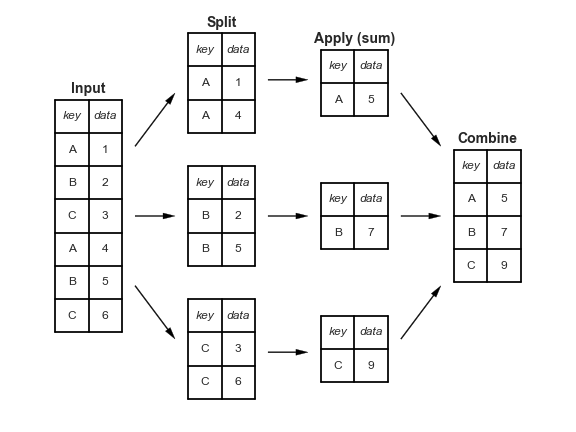

Source: Python Data Science Handbook

This explains what `groupby` accomplishes:

- The *split* step involves breaking up and grouping a DataFrame depending on the value of the specified key
- The *apply* step involves computing some function, usually an aggregate, transformation, or filtering, within the individual groups
- The *combine* step merges the results of these operations into an output array

```python
df = pd.DataFrame({'key': ['A', 'B', 'C', 'A', 'B', 'C'],
                   'data': range(6)}, columns=['key', 'data'])
df
```

```
  key  data
0   A     0
1   B     1
2   C     2
3   A     3
4   B     4
5   C     5
```

```python
df.groupby("key").sum()
```

```
     data
key
A       3
B       5
C       7
```